# Intro to R part 1

## Setting a working directory and reading .csv files

### Setting a working directory

The working directory is the directory on your computer where R will retrieve and store data as well as save outputs such as plots and spreadsheets.

For this class, you should maintain a consistent file structure such that you can always code in it.

For example, on your local desktop, you might start a folder called “FisheriesManagement”, with subfolders such as “Lab1 - Intro to R part1”, “Lab2 - Intro to R part2”, “Lab3 - Fisheries Data Visualization” etc., so that you can easily tell R where to save and retrieve files. There are three ways to set your working directory.

```
    |-- FisheriesManagement/                   <- root directory
        |-- Lab_1/
            |-- Lab1.Rmd
            |-- Lab1.R
            |-- allcatch.csv
            |-- lab1_testdata.csv
        |-- Lab_2/
```

1. In the menu bar, click on “Session” and then select “Set Working Directory” from the drop-down menu. Select “Choose Directory…” and navigate to the desired folder.
2. In your pane with the following tabs: Files, Plots, Packages, Help, and Viewer (Default position is bottom right). After selecting “Files”, navigate to the desired folder and click “More” (the gear icon) and then “Set as Working Directory”.
3. The command to set your working directory is `setwd()`. Everyone’s home directory will not be the same.

I highly recommend to use option 3 because it is faster and does not require clicking. So, create a file structure like the one outlined above.

```r
getwd()
```

```
## [1] "/mnt/c/Users/Jeremy/Dropbox/FisheriesManagement2023/Lab1 - Intro to R part1"
```

Here is a trick to get the directory of the file you are working on. This should typically go at the top of your Rmarkdown file

```r
lab_path = dirname(rstudioapi::getSourceEditorContext()$path)
knitr::opts_knit$set(root.dir = lab_path)
getwd()
```

```
## [1] "/mnt/c/Users/Jeremy/Dropbox/FisheriesManagement2023/Lab1 - Intro to R part1"
```

### Reading a .csv file

Once you have set your working directory, you can read in the data using the `read.csv()` function.

```r
list.files()
```

```
## [1] "allcatch.csv"                  "Intro to R part 1_Davis_K.Rmd"
## [3] "Intro-to-R-part-1_Davis_K.Rmd" "Lab1_files"
## [5] "lab1_testdata.csv"             "Lab1.docx"
## [7] "Lab1.html"                     "Lab1.Rmd"
```

```r
usa_landings <- read.csv("lab1_testdata.csv")
```

### Saving dataframes

```r
write.csv(allcatch, "allcatch.csv", row.names = FALSE) # writes the dataframe that we created earlier
list.files()
```

### Exploring the new dataframe

This dataset describes the total catch reported to the Food and Agriculture Organization (FAO) by the USA for the years 1950-2018.

```r
paste("Catch average:",mean(usa_landings$catch))
```

```
## [1] "Catch average: 3967149.96028986"
```

```r
paste("Catch standard deviation:",sd(usa_landings$catch))
```

```
## [1] "Catch standard deviation: 1165877.26111905"
```

```r
summary(usa_landings)
```

```
##       year          catch           country
##  Min.   :1950   Min.   :2311726   Length:69
##  1st Qu.:1967   1st Qu.:2772595   Class :character
##  Median :1984   Median :4229471   Mode  :character
##  Mean   :1984   Mean   :3967150
##  3rd Qu.:2001   3rd Qu.:4998490
##  Max.   :2018   Max.   :5694242
```

## Scripts

Scripts allow you to save and modify your code. You can open a script under File - New File - New R Script.

Type your code directly into the script, and run individual lines of code either by clicking “Run” at the top of the script, or using the shortcut Cmd-Enter (Mac) / Ctrl-Enter (Windows).

You can annotate your code with information that helps you to understand each line by commenting after the symbol `#` in a code line.

```r
# anything written after '#' will not be run as code
1+1 # A simple calculation
```

```
## [1] 2
```

## Using Packages

Packages offer different objects, functions, and data Get the list of all loaded packages

```r
search()
```

```
## [1] ".GlobalEnv"        "package:stats"     "package:graphics"
## [4] "package:grDevices" "package:utils"     "package:datasets"
## [7] "package:methods"   "Autoloads"         "package:base"
```

We are going to install `tidyverse`, which is a collection of several frequently used packages including `ggplot`, `dplyr`, and `tidyr`.

```r
# install.packages("tidyverse")
```

```r
# load the package
library(tidyverse)
```

```r
more_usa_landings = data.frame(year=c(1952, 1956), catch=c(40000, 20000), country="USA")
merge(usa_landings, more_usa_landings, by="year")
```

```
##   year catch.x country.x catch.y country.y
## 1 1952 2472565       USA   40000       USA
## 2 1956 2795334       USA   20000       USA
```

## Plotting in Base R

The Base R packages allow for some basic plotting through the `plot()` function. The default plot type will be a scatter plot. To plot the catches from our `usa_landings` dataframe, we can use the following code:

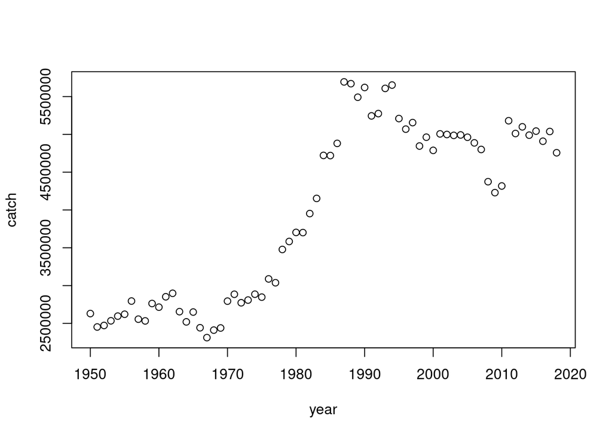

```r
plot(data=usa_landings, catch~year)
```

We can also use the `$` operator

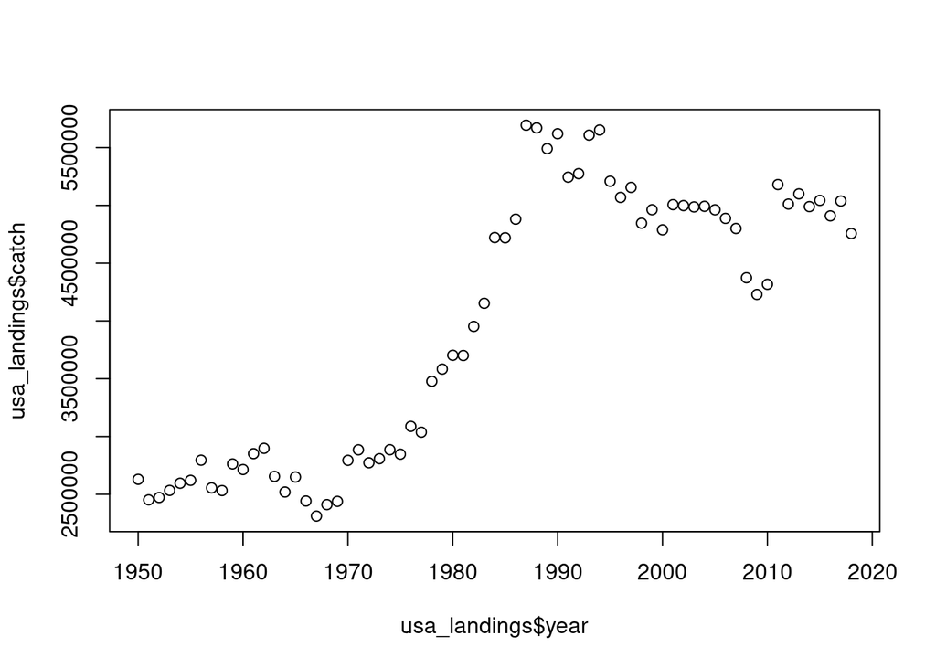

```r
plot(usa_landings$catch~usa_landings$year)
```

Now, see what else the `plot` function can do with `?plot`

```r
?plot
```

```
## Help on topic 'plot' was found in the following packages:
##
##   Package               Library
##   graphics              /usr/lib/R/library
##   base                  /usr/lib/R/library
##
##
## Using the first match ...
```

```r
# Select Generic X-Y Plotting and scroll down to see different arguments the function accepts
```

This works for all functions. We can see in this case that we can change the plot style; for example, we can create the same plot as a line plot

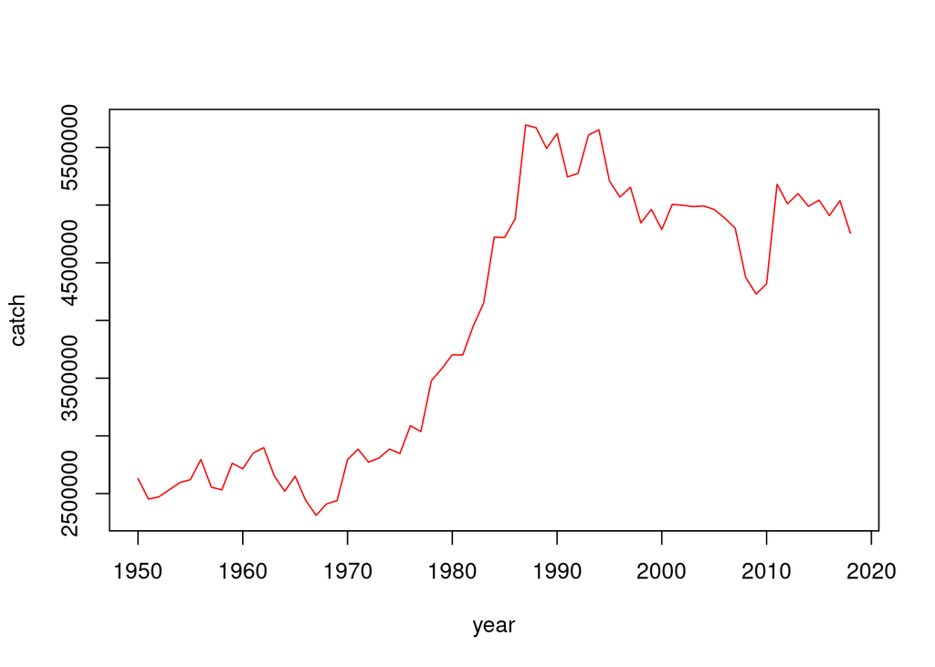

```r
plot(catch~year, data=usa_landings, type="l", col='red')
```

## Plotting in `ggplot`

`ggplot` is a commonly used package for plotting as it is highly customizable. Plots are created by defining `geom` objects, such as points, lines, or polygons. There are numerous ggplot guides available which discuss how different plot components can be customized.

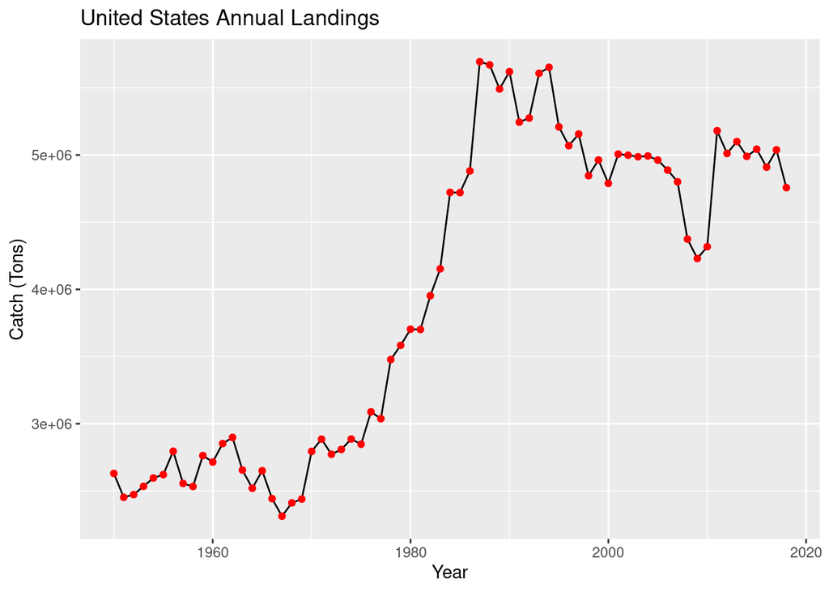

```r
ggplot(usa_landings) + # ggplot loads in the data and uses '+' to add properties
  geom_line(aes(x=year, y=catch)) + # creates the line plot
  geom_point(aes(x=year, y=catch), color="red") + # adds red points for each value
  ylab("Catch (Tons)") + # y axis title
  xlab("Year") + # x axis title
  ggtitle("United States Annual Landings") # main plot title
```

`ggplot` allows you to customize axes, labels, legends, line and shape styles, and most any other aspect of the plot you may want to modify. Look online at the available guides for additional information on plotting in ggplot.

[bookdown_ggplot](https://bookdown.org/rdpeng/RProgDA/basic-plotting-with-ggplot2.html)

## Using packages and functions to access data

```r
# install.packages("rfisheries")
# install.packages("FSAdata")
```

```r
library(rfisheries)
library(FSAdata)
```

The `rfisheries` package provides access to the Open Fisheries global fisheries data - including the total annual number of *landings* for each year. The `FSA` package records biological fisheries data from the Global Fisheries Stock Assessment organization.

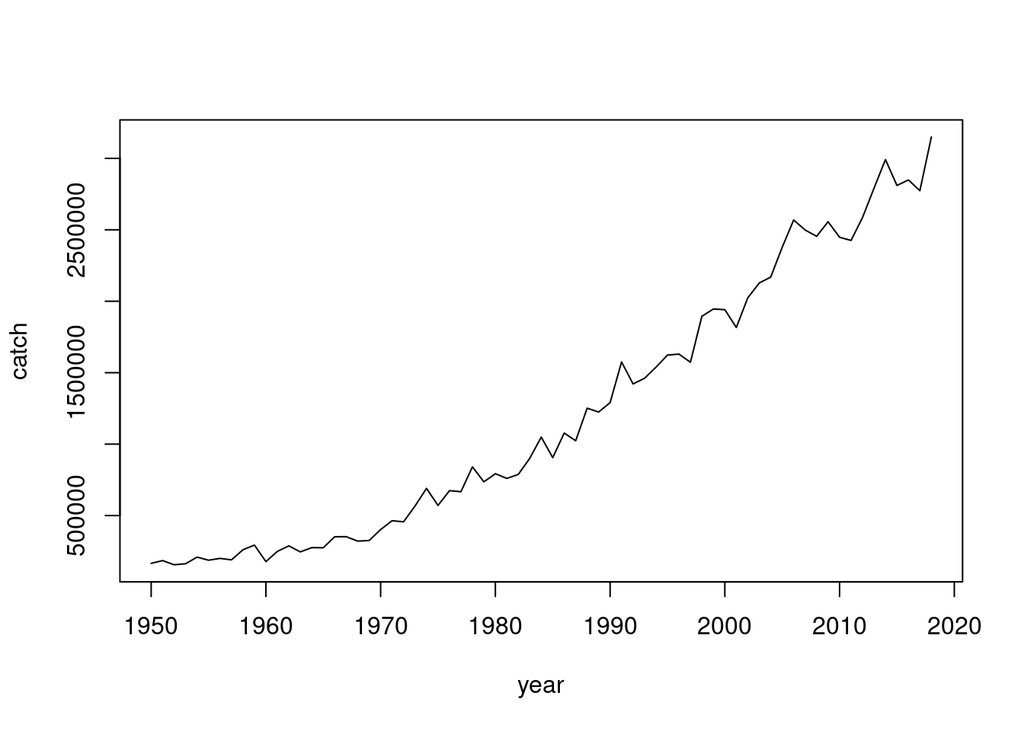

```r
annual.landings = of_landings(species="SKJ") # Global landings of skipkack tuna
plot(data=annual.landings, catch~year, type='l')
```

What does the function `of_landings()` do?

```r
?of_landings
```

Plot by country with a country-specific code

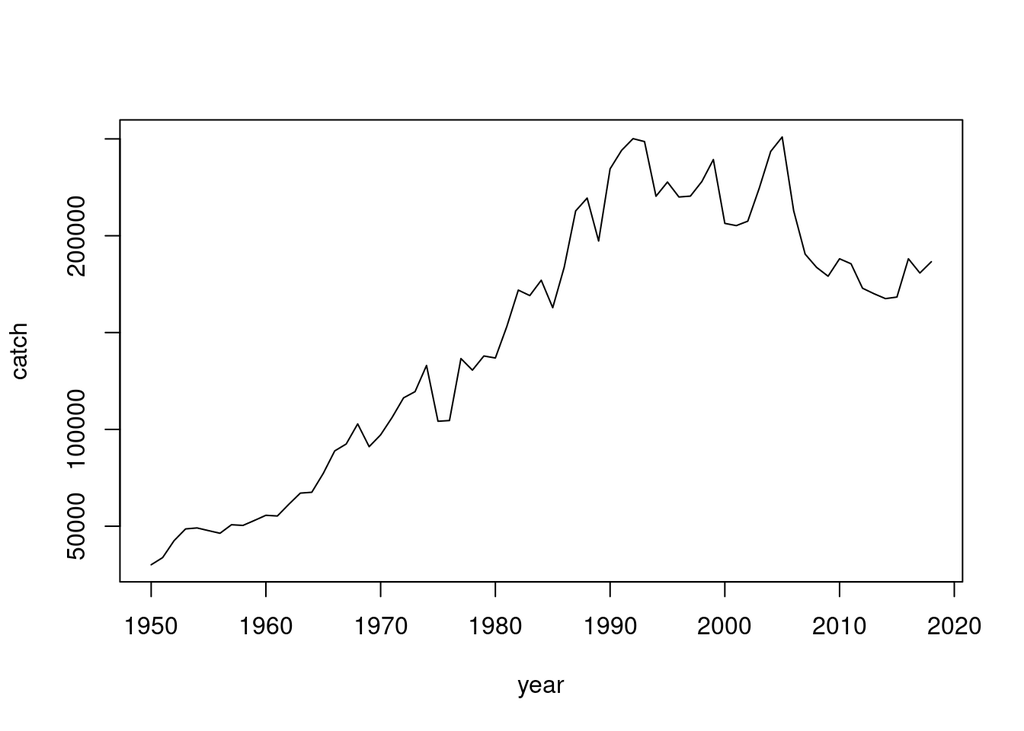

```r
annual.landings.usa = of_landings(country="AUS") # Total landings from Australia
plot(data=annual.landings.usa, catch~year, type='l')
```

Use `ggplot` to plot landings of `Red Drum` and annotate the axes and title.

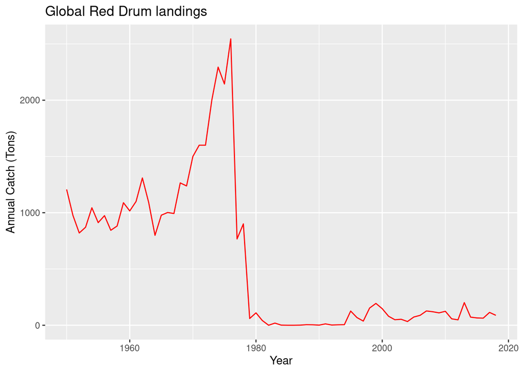

```r
RDM_landings = of_landings(species="RDM")
ggplot(RDM_landings) +
  geom_line(aes(x=year, y=catch), col="red") +
  ylab("Annual Catch (Tons)")+
  xlab("Year")+
  ggtitle("Global Red Drum landings")
```

We can plot biological data using the `FSA` package

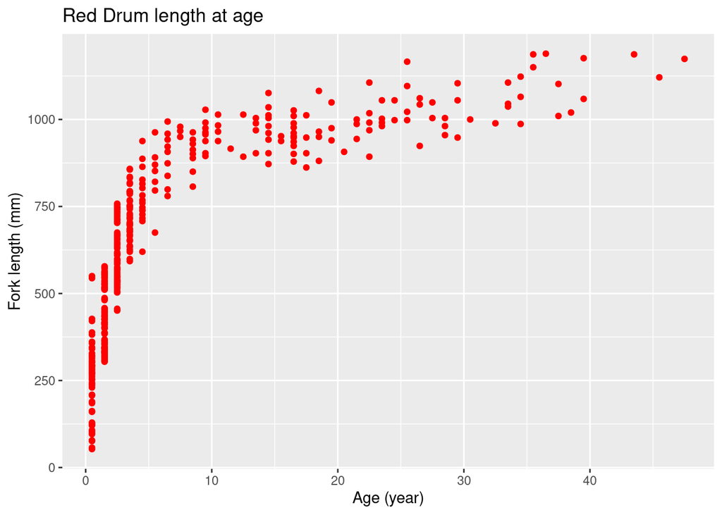

```r
data(RedDrum) # loads FSA data for Red Drum biological entries
ggplot(RedDrum) +
  geom_point(aes(x=age, y=fl), col="red") + # using points instead of a line
  ylab("Fork length (mm)")+
  xlab("Age (year)")+
  ggtitle("Red Drum length at age")
```

# Assignment instructions

Choose *1 country* and *1 species* from `rfisheries`, and *2 species* from `FSAdata`. Explore the data with statistical functions and summaries, and visualize the data with plots. Keep track of your report with RMarkdown and when you are finished, Knit the file to Word (you can knit to HTML first to see if it compiles without error).

Find all countries from `rfisheries`

```r
of_country_codes() # `head()` prints the top of the output, and leaves out the rest
```

```
##                       country iso3c
## 1                 Afghanistan   AFG
## 2                     Albania   ALB
## 3                     Algeria   DZA
## 4              American Samoa   ASM
## 5                     Andorra   AND
## 6                      Angola   AGO
## 7                    Anguilla   AIA
## 8         Antigua and Barbuda   ATG
## 9                   Argentina   ARG
## 10                    Armenia   ARM
## 11                      Aruba   ABW
## 12                  Australia   AUS
## 13                    Austria   AUT
## 14                 Azerbaijan   AZE
```

[output cut: 225 more lines]

Find all species from `rfisheries`

```r
of_species_codes()
```

```
##                             scientific_name      taxocode a3_code isscaap
## 1                        Petromyzon marinus    1020100101     LAU      25
## 2                      Lampetra fluviatilis    1020100201     LAR      25
## 3                       Lampetra tridentata    1020100202     LAO      25
## 4                    Ichthyomyzon unicuspis    1020100401     LAY      25
## 5                       Eudontomyzon mariae    1020100501     LAF      25
## 6                         Geotria australis    1020100701     LAE      25
## 7                           Mordacia mordax    1020100801     LAK      25
## 8                       Caspiomyzon wagneri    1020100901     LAW      25
## 9                 Lethenteron camtschaticum    1020101101     LSZ      25
## 10                          Petromyzontidae    10201XXXXX     LAS      25
## 11                         Paramyxine atami    1030300201     MYP      33
## 12                         Myxine glutinosa    1030300301     MYG      33
## 13                      Nemamyxine elongata    1030300401     MYE      33
## 14                       Eptatretus burgeri    1030300601     MYB      33
```

[output cut: 23111 more lines]

Use `of_landings()` with country OR species arguments

Find all species from `FSA` [FSAdata](http://derekogle.com/fishR/data/byPackage) Load species data with

```r
# data([insert species name])
# example
data(Bonito)
head(Bonito)
```

```
##      sex       age   fl
## 1 Female 0.1666667 30.3
## 2 Female 0.1666667 30.5
## 3 Female 0.1666667 28.8
## 4 Female 0.1666667 26.3
## 5 Female 0.1666667 31.9
## 6 Female 0.1666667 32.4
```

## Assignment 1

```r
#rfisheries

head(of_country_codes())
```

```
##          country iso3c
## 1    Afghanistan   AFG
## 2        Albania   ALB
## 3        Algeria   DZA
## 4 American Samoa   ASM
## 5        Andorra   AND
## 6         Angola   AGO
```

```r
head(of_species_codes())
```

```
##          scientific_name   taxocode a3_code isscaap            english_name
## 1     Petromyzon marinus 1020100101     LAU      25             Sea lamprey
## 2   Lampetra fluviatilis 1020100201     LAR      25           River lamprey
## 3    Lampetra tridentata 1020100202     LAO      25         Pacific lamprey
## 4 Ichthyomyzon unicuspis 1020100401     LAY      25          Silver lamprey
## 5    Eudontomyzon mariae 1020100501     LAF      25 Ukrainian brook lamprey
## 6      Geotria australis 1020100701     LAE      25         Pouched lamprey
```

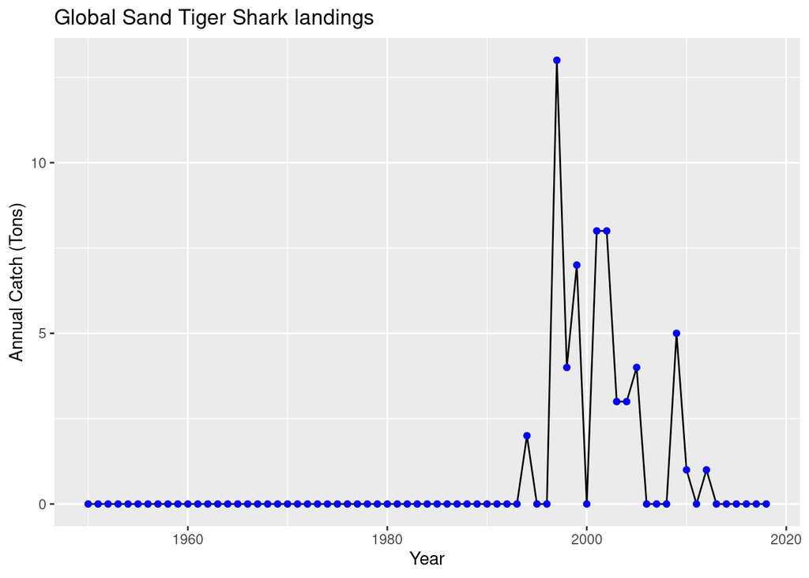

```r
annual.landings = of_landings(species = "CCT")
ggplot(annual.landings) +
  geom_line(aes(x=year, y=catch)) +
  geom_point(aes(x=year, y=catch), color="blue") +
  ylab("Annual Catch (Tons)") +
  xlab("Year") +
  ggtitle("Global Sand Tiger Shark landings")
```

```r
mean(annual.landings$catch)
```

```
## [1] 0.8550725
```

```r
sd(annual.landings$catch)
```

```
## [1] 2.353192
```

```r
summary(annual.landings$catch)
```

```
##    Min. 1st Qu.  Median    Mean 3rd Qu.    Max.
##  0.0000  0.0000  0.0000  0.8551  0.0000 13.0000
```

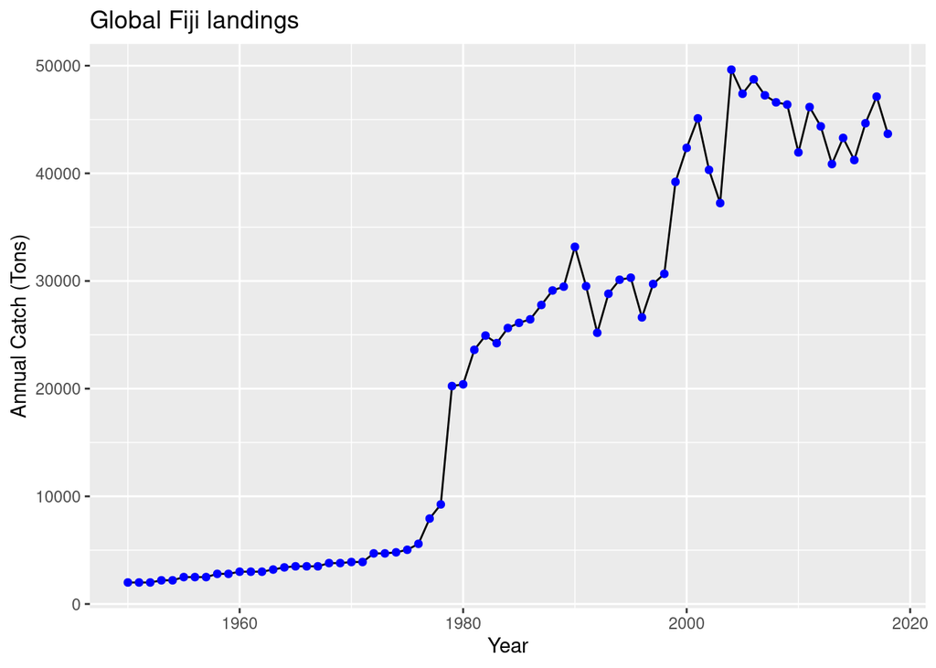

```r
annual.landings_1 = of_landings(country="FJI")
ggplot(annual.landings_1) +
  geom_line(aes(x=year, y=catch)) +
  geom_point(aes(x=year, y=catch), color="blue") +
  ylab("Annual Catch (Tons)") +
  xlab("Year") +
  ggtitle("Global Fiji landings")
```